# Упражнение 9

Никишов Дмитрий

12 05 2021

Необходимо построить модель на основе SVM для указанной в варианте зависимой переменной.

Данные взять из упражнения №3.

Для модели:

1 Отложить 25% наблюдений в тестовую выборку (ядро генератора случайных чисел указано в варианте к упражнению №3).

2 На обучающей выборке (оставшихся 75% наблюдений) сравнить несколько видов ядер SVM по точности модели (AUC) методом сеточного поиска.

3 Для оптимальной формы ядерной функции на обучающей выборке подобрать оптимальное значение настроечных параметров по минимальной ошибке с перекрёстной проверкой (функция tune).

4 Подогнать лучшую модель на всей обучающей выборке. Построить ROC-кривую и рассчитать матрицу неточностей, чувствительность и специфичность.

5 Сделать прогноз по лучшей модели на тестовую выборку, оценить его качество точность по матрице неточностей, чувствительность и специфичность, построить ROC-кривую.

6 Сравнить результаты, которые дал SVM, с результатами, полученными в упражнении 3. Какой из методов оказался лучше?

## Вариант 21 (3)

- Ядро для set.seed() - 123.
- Данные: *PimaIndiansDiabetes{mlbench}* - случаи диабета у женщин индейского племени Пима.
- Зависимая переменная: *diabetes* (*pos* - наличие признака, *neg* - отсутствие).
- Объясняющие переменные: Все остальные.
- Методы: *Логистическая регрессия, QDA*.

Пакеты:

Зададим ядро генератора случайных чисел и объём обучающей выборки.

```r
my.seed <- 123        # Ядро генерации
train.percent <- 0.75 # Доля обучающей выборки
```

- Исходные данные: *PimaIndiansDiabetes{mlbench}* - случаи диабета у женщин индейского племени Пима

```r
data(PimaIndiansDiabetes)
head(PimaIndiansDiabetes)
```

```
##   pregnant glucose pressure triceps insulin mass pedigree age diabetes
## 1        6     148       72      35       0 33.6    0.627  50      pos
## 2        1      85       66      29       0 26.6    0.351  31      neg
## 3        8     183       64       0       0 23.3    0.672  32      pos
## 4        1      89       66      23      94 28.1    0.167  21      neg
## 5        0     137       40      35     168 43.1    2.288  33      pos
## 6        5     116       74       0       0 25.6    0.201  30      neg
```

```r
dim(PimaIndiansDiabetes)
```

```
## [1] 768   9
```

```r
diabetes <- rep(0, length(PimaIndiansDiabetes$diabetes)) # Создание вектора diabetes
PimaIndiansDiabetes <- cbind(PimaIndiansDiabetes, diabetes)        # Присоединение diabetes к фрейму PimaIndiansDiabetes

# Замена в переменной diabetes: если diabetes = pos означает наличие признака (1), neg - отсутствие(0)
for(i in 1:length(PimaIndiansDiabetes$diabetes)) {if (PimaIndiansDiabetes$diabetes[i] == "pos") {PimaIndiansDiabetes$diabetes[i] == "neg"}}

# Определение долей
table(PimaIndiansDiabetes$diabetes) / sum(table(PimaIndiansDiabetes$diabetes))
```

```
##
##       neg       pos
## 0.6510417 0.3489583
```

# Сеточный поиск

```r
#Отбираем наблюдения в обучающую выборку
set.seed(my.seed)
inTrain <- sample(seq_along(PimaIndiansDiabetes$diabetes),
                  nrow(PimaIndiansDiabetes)*train.percent)
xtrain <- PimaIndiansDiabetes[inTrain, c(-9, -10)]
xtest <- PimaIndiansDiabetes[-inTrain, c(-9, -10)]
ytrain <- PimaIndiansDiabetes[inTrain, 9]
ytest <- PimaIndiansDiabetes[-inTrain, 9]

# Обучающая выборка
dat <- data.frame(x = xtrain, y = as.factor(ytrain))

# Тестовые данные
dat.te <- data.frame(x = xtest, y = as.factor(ytest))

# Параметры алгоритма
kernel.grid <- c('linear', 'polynomial')
cost.grid <- seq(1, 20, by = 0.5)

AUC <- matrix(0, length(kernel.grid), length(cost.grid))
colnames(AUC) <- paste0('cost = ', cost.grid)
rownames(AUC) <- paste0('kernel = ', kernel.grid)

# SVM
for (i in 1:length(kernel.grid)) {
    print(paste0('Starting ', kernel.grid[i], ' kernel'))
    for (j in 1:length(cost.grid)) {
        out <- svm(y ~ ., data = dat, kernel = kernel.grid[i],
                   cost = cost.grid[j])
        # Прогноз на тестовой выборке
        pred.te <- predict(out, newdata = dat.te)
        # Матрица неточностей
        tbl <- table(pred.te, dat.te$y)
        AUC[i, j] <- sum(diag(tbl)) / sum(tbl)
    }
}
```

```
## [1] "Starting linear kernel"
## [1] "Starting polynomial kernel"
```

```r
round(AUC, 3)
```

```
##                     cost = 1 cost = 1.5 cost = 2 cost = 2.5 cost = 3 cost = 3.5
## kernel = linear        0.760      0.760    0.766      0.766    0.766      0.766
## kernel = polynomial    0.703      0.693    0.698      0.693    0.698      0.693
##                     cost = 4 cost = 4.5 cost = 5 cost = 5.5 cost = 6 cost = 6.5
## kernel = linear        0.766      0.766    0.766      0.766    0.766      0.766
## kernel = polynomial    0.698      0.703    0.703      0.698    0.693      0.693
##                     cost = 7 cost = 7.5 cost = 8 cost = 8.5 cost = 9 cost = 9.5
## kernel = linear        0.766      0.766    0.766      0.766    0.766      0.766
## kernel = polynomial    0.693      0.693    0.693      0.693    0.698      0.698
##                     cost = 10 cost = 10.5 cost = 11 cost = 11.5 cost = 12
## kernel = linear         0.766       0.766     0.766       0.766     0.766
## kernel = polynomial     0.698       0.698     0.688       0.688     0.682
##                     cost = 12.5 cost = 13 cost = 13.5 cost = 14 cost = 14.5
## kernel = linear           0.766     0.766       0.766     0.766       0.766
## kernel = polynomial       0.682     0.677       0.677     0.677       0.677
##                     cost = 15 cost = 15.5 cost = 16 cost = 16.5 cost = 17
## kernel = linear         0.766       0.766     0.766       0.766     0.766
## kernel = polynomial     0.677       0.677     0.682       0.682     0.682
##                     cost = 17.5 cost = 18 cost = 18.5 cost = 19 cost = 19.5
## kernel = linear           0.766     0.766       0.766     0.766       0.766
## kernel = polynomial       0.688     0.682       0.682     0.677       0.677
##                     cost = 20
## kernel = linear         0.766
## kernel = polynomial     0.677
```

Из полученных результатов видно, что оптимальной формой ядерной функции будет линейная модель.

# Оптимальное значение настроечного параметра

```r
# Классификатор на опорных векторах с линейной границей
svmfit <- svm(y ~ ., data = dat, kernel = "linear", cost = 10, cale = FALSE)

# Список опорных векторов
svmfit$index
```

```
##   [1]   1   7   9  10  12  15  18  20  23  26  34  37  38  40  47  48  49  56
##  [19]  60  63  65  71  78  82  84  85  86  87  91  98  99 101 108 114 115 122
##  [37] 123 129 139 141 143 144 147 151 154 155 156 172 174 177 182 184 186 195
##  [55] 199 203 204 207 213 216 221 223 227 235 237 240 244 246 254 256 257 264
##  [73] 266 270 279 281 283 288 289 295 297 306 308 321 327 331 334 337 346 347
##  [91] 354 357 359 363 368 378 380 381 383 384 394 398 404 407 408 412 417 421
## [109] 423 429 430 432 436 437 439 440 442 444 445 454 457 459 460 468 469 478
## [127] 479 484 489 490 493 508 515 519 520 524 525 526 529 539 540 544 545 547
## [145] 553 558 564 572 575   3   8  17  31  36  39  41  43  45  50  54  57  66
## [163]  75  76  80  83  90  92  96  97 103 104 110 124 125 126 127 130 133 146
## [181] 152 153 166 167 171 175 176 181 185 187 188 190 191 196 198 200 201 205
## [199] 206 228 230 231 238 243 249 251 252 258 260 263 267 268 272 277 278 285
## [217] 287 290 291 292 293 294 296 298 299 300 303 314 315 319 322 324 326 328
## [235] 330 333 335 339 340 341 344 348 350 351 352 353 355 362 365 377 388 389
## [253] 390 392 397 399 400 403 405 414 422 424 425 449 450 451 452 455 461 465
## [271] 466 467 470 472 473 477 480 492 499 500 503 504 507 517 523 527 531 533
## [289] 536 537 541 560 562 563 569 571 573 576
```

```r
# Сводка по модели
summary(svmfit)
```

```
##
## Call:
## svm(formula = y ~ ., data = dat, kernel = "linear", cost = 10, cale = FALSE)
##
##
## Parameters:
##    SVM-Type:  C-classification
##  SVM-Kernel:  linear
##        cost:  10
##
## Number of Support Vectors:  298
##
##  ( 149 149 )
##
##
## Number of Classes:  2
##
## Levels:
##  neg pos
```

Делаем перекрёстную проверку, изменяя штраф (аргумент cost)

```r
#
set.seed(my.seed)
tune.out <- tune(svm, y ~ ., data = dat, kernel = "linear",
                 ranges = list(cost = c(0.001, 0.1, 1, 5, 10, 100)))
summary(tune.out)
```

```
##
## Parameter tuning of 'svm':
##
## - sampling method: 10-fold cross validation
##
## - best parameters:
##  cost
##   0.1
##
## - best performance: 0.2205384
##
## - Detailed performance results:
##    cost     error dispersion
## 1 1e-03 0.3488203 0.06970869
## 2 1e-01 0.2205384 0.05311331
## 3 1e+00 0.2257108 0.05299995
## 4 5e+00 0.2257108 0.05299995
## 5 1e+01 0.2257108 0.05299995
## 6 1e+02 0.2257108 0.05299995
```

# Лучшая модель на всей обучающей выборке

```r
# Лучшая модель -- с минимальной ошибкой
bestmod <- tune.out$best.model
summary(bestmod)
```

```
##
## Call:
## best.tune(method = svm, train.x = y ~ ., data = dat, ranges = list(cost = c(0.001,
##     0.1, 1, 5, 10, 100)), kernel = "linear")
##
##
## Parameters:
##    SVM-Type:  C-classification
##  SVM-Kernel:  linear
##        cost:  0.1
##
## Number of Support Vectors:  309
##
##  ( 153 156 )
##
##
## Number of Classes:  2
##
## Levels:
##  neg pos
```

```r
# Делаем прогноз по лучшей модели
ypred_tr <- predict(bestmod, dat)

# Матрица неточностей
tbl1 <- table(Predicts = ypred_tr, Fact = dat$y)
tbl1
```

```
##         Fact
## Predicts neg pos
##      neg 334  87
##      pos  41 114
```

```r
# Чувствительность
TPR <- round(tbl1[2,2]/sum(tbl1[2,]),3)
TPR
```

```
## [1] 0.735
```

```r
# Специфичность
SPC <- round(tbl1[1,1]/sum(tbl1[1,]),3)
SPC
```

```
## [1] 0.793
```

```r
# Функция построения ROC-кривой: pred -- прогноз, truth -- факт
rocplot <- function(pred, truth, ...){
    predob = prediction(pred, truth)
    perf = performance(predob, "tpr", "fpr")
    plot(perf,...)}

# Оптимальная модель
svmfit.opt <- svm(y ~ ., data = dat, kernel = "linear",  cost = 0.01, probability = T)

# Матрица неточностей на обучающей (p = 0.01)
table(Predicts = predict(svmfit.opt, dat),
             Fact = dat$y)
```

```
##         Fact
## Predicts neg pos
##      neg 340  93
##      pos  35 108
```

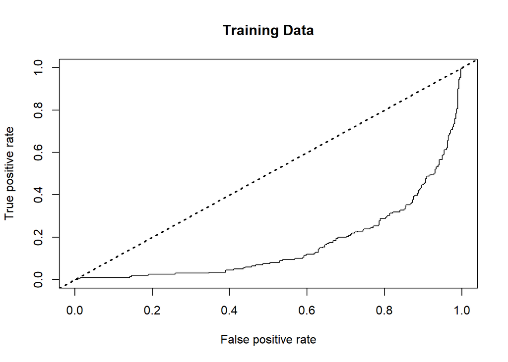

```r
# Прогноз вероятностей, на основе которых присваивается класс
fitted.prob <- predict(svmfit.opt, dat, type = "prob",  probability = TRUE)
fitted.prob <- attr(fitted.prob, "probabilities")[, 2]

# График для обучающей выборки
# ROC-кривая для первой модели
rocplot(fitted.prob, dat[, "y"], main = "Training Data")
# Прямая случайного классификатора
abline(a = 0, b = 1, lty = 3, lwd = 2)
```

# Лучшая модель на тестовой выборке

```r
# График для тестовой выборки
fitted.prob <- predict(svmfit.opt, dat.te, type = "prob",
                       probability = TRUE)
fitted.prob <- attr(fitted.prob, "probabilities")[, 2]

# Матрица неточностей на тестовой (p = 0.01)
tbl2 <- table(Predicts = predict(svmfit.opt, dat.te), Fact = dat.te$y)
tbl2
```

```
##         Fact
## Predicts neg pos
##      neg 116  36
##      pos   9  31
```

```r
# Точность
ACC <- round(sum(diag(tbl2))/sum(tbl2),3)
ACC
```

```
## [1] 0.766
```

```r
# Чувствительность
TPR <- round(tbl2[2,2]/sum(tbl2[2,]),3)
TPR
```

```
## [1] 0.775
```

```r
# Специфичность
SPC <- round(tbl2[1,1]/sum(tbl2[1,]),3)
SPC
```

```
## [1] 0.763
```

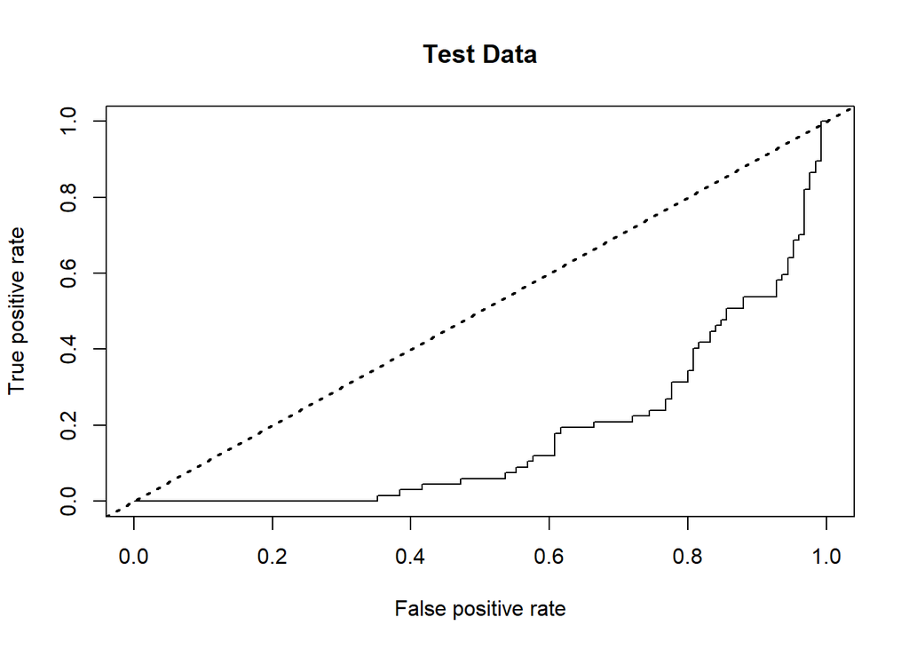

```r
# ROC-кривая для тестовой выборки
rocplot(fitted.prob, dat.te$y, main = "Test Data")
# Прямая случайного классификатора
abline(a = 0, b = 1, lty = 3, lwd = 2)
```

# Сравнение моделей (логистическая регрессия, LDA, SVM) на тестовой выборке

```r
# логистическая регрессия
model.logit <- glm(y ~ ., data = dat, family = 'binomial')
summary(model.logit)
```

```
##
## Call:
## glm(formula = y ~ ., family = "binomial", data = dat)
##
## Deviance Residuals:
##     Min       1Q   Median       3Q      Max
## -2.3897  -0.7185  -0.4143   0.7171   2.9929
##
## Coefficients:
##              Estimate Std. Error z value Pr(>|z|)
## (Intercept) -8.439467   0.818894 -10.306  < 2e-16 ***
## x.pregnant   0.116520   0.037504   3.107  0.00189 **
## x.glucose    0.036804   0.004438   8.293  < 2e-16 ***
## x.pressure  -0.013655   0.005931  -2.302  0.02131 *
## x.triceps    0.004829   0.007856   0.615  0.53875
## x.insulin   -0.001352   0.001011  -1.337  0.18117
## x.mass       0.085151   0.017263   4.932 8.12e-07 ***
## x.pedigree   0.719555   0.329791   2.182  0.02912 *
## x.age        0.015870   0.010877   1.459  0.14456
## ---
## Signif. codes:  0 '***' 0.001 '**' 0.01 '*' 0.05 '.' 0.1 ' ' 1
##
## (Dispersion parameter for binomial family taken to be 1)
##
##     Null deviance: 745.11  on 575  degrees of freedom
## Residual deviance: 538.57  on 567  degrees of freedom
## AIC: 556.57
##
## Number of Fisher Scoring iterations: 5
```

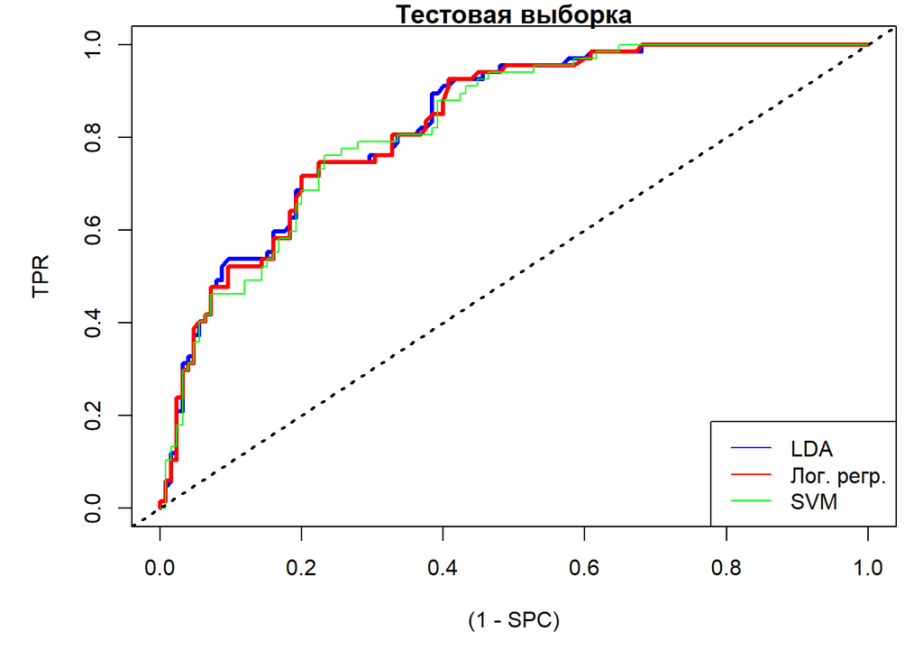

```r
p.logit <- predict(model.logit, dat.te,
                  type = 'response')

Forecast1 <- factor(ifelse(p.logit > 0.5, 2, 1),
                  levels = c(1, 2),
                  labels = c('neg', 'pos'))

# считаем 1-SPC и TPR для всех вариантов границы отсечения
x1 <- NULL    # для (1 - SPC)
y1 <- NULL    # для TPR

# заготовка под матрицу неточностей
# Заготовка под матрицу неточностей
tbl1 <- as.data.frame(matrix(rep(0, 4), 2, 2))
rownames(tbl1) <- c('fact.neg', 'fact.pos')
colnames(tbl1) <- c('predict.neg', 'predict.pos')

# цикл по вероятностям отсечения
for (p in seq(0, 1, length = 501)){
    # прогноз
    Forecast1 <- factor(ifelse(p.logit > p, 2, 1),
                        levels = c(1, 2),
                        labels = c('neg', 'pos'))

    # фрейм со сравнением факта и прогноза
    df.compare <- data.frame(Fact = dat.te$y, Forecast = Forecast1)

    # заполняем матрицу неточностей
    tbl1[1, 1] <- nrow(df.compare[df.compare$Fact == 'neg' & df.compare$Forecast == 'neg', ])
    tbl1[2, 2] <- nrow(df.compare[df.compare$Fact == 'pos' & df.compare$Forecast == 'pos', ])
    tbl1[1, 2] <- nrow(df.compare[df.compare$Fact == 'neg' & df.compare$Forecast == 'pos', ])
    tbl1[2, 1] <- nrow(df.compare[df.compare$Fact == 'pos' & df.compare$Forecast == 'neg', ])

    # считаем характеристики
    TPR <- tbl1[2, 2] / sum(tbl1[2, ])
    y1 <- c(y1, TPR)
    SPC <- tbl1[1, 1] / sum(tbl1[1, ])
    x1 <- c(x1, 1 - SPC)
    }



# LDA
model.lda <- lda(y ~ ., data = dat)

# Прогноз: вероятности принадлежности классу diabetes
p.lda <- predict(model.lda, dat.te, type = 'response')

x2 <- NULL    # для (1 - SPC)
y2 <- NULL    # для TPR

# Заготовка под матрицу неточностей
tbl2 <- as.data.frame(matrix(rep(0, 4), 2, 2))
rownames(tbl2) <- c('fact.neg', 'fact.pos')
colnames(tbl2) <- c('predict.neg', 'predict.pos')


# вектор вероятностей для перебора
#p.vector <- seq(0, 1, length = 501)

# цикл по вероятностям отсечения
for (p in seq(0, 1, length = 501)){
  # Прогноз
  Forecast2 <- factor(ifelse(p.lda$posterior[, 'pos'] > p, 2, 1),
                      levels = c(1, 2),
                      labels = c('neg', 'pos'))

  # фрейм со сравнением факта и прогноза
  df.compare <- data.frame(Fact = dat.te$y, Forecast = Forecast2)

  # Заполняем матрицу неточностей
  tbl2[1, 1] <- nrow(df.compare[df.compare$Fact == 'neg' & df.compare$Forecast == 'neg', ])
  tbl2[2, 2] <- nrow(df.compare[df.compare$Fact == 'pos' & df.compare$Forecast == 'pos', ])
  tbl2[1, 2] <- nrow(df.compare[df.compare$Fact == 'neg' & df.compare$Forecast == 'pos', ])
  tbl2[2, 1] <- nrow(df.compare[df.compare$Fact == 'pos' & df.compare$Forecast == 'neg', ])

  # Считаем характеристики
  TPR <- tbl2[2, 2] / sum(tbl2[2, ])
  y2 <- c(y2, TPR)
  SPC <- tbl2[1, 1] / sum(tbl2[1, ])
  x2 <- c(x2, 1 - SPC)
}




# Строим ROC-кривую
par(mar = c(5, 5, 1, 1))

# кривая (логистическая регрессия)
plot(x1, y1, type = 'l', col = 'blue', lwd = 3,
     xlab = '(1 - SPC)', ylab = 'TPR',
     xlim = c(0, 1), ylim = c(0, 1), main = 'Тестовая выборка')

# кривая (LDA)
lines(x2, y2, type = 'l', col = 'red', lwd = 3)

# Кривая (SVM обр.)
rocplot(-fitted.prob, dat.te$y, add = T, col = 'green')

# Прямая случайного классификатора
abline(a = 0, b = 1, lty = 3, lwd = 2)

# Легенда
legend('bottomright', names <-  c('LDA', 'Лог. регр.', 'SVM'), lty = 1, col = c('blue', 'red', 'green'))
```